# Phase 2- PREDICTING CANCER BIOPSY RESULT

Jasika Verma 3989980 Priya Madabal 3959738

## INTRODUCTION

### Summary of Phase 1

In Phase 1 of the project, we utilized the Predicting Cervical Cancer dataset sourced from Kaggle (RANZEET RAUT, 2023), which includes 36 features and 835 observations related to demographic data, sexual behavior, smoking habits, contraceptive usage, history of sexually transmitted diseases (STDs), and diagnostic outcomes pertinent to cervical cancer. The primary focus was on data cleaning, preprocessing, and exploratory data analysis (EDA). Irrelevant variables were removed, and data integrity was ensured by addressing missing values and outliers. We gained insights into the distribution and relationships within the dataset, employing visualizations to reveal trends such as the prevalence of cervical cancer risk factors across different demographic groups and the impact of certain behaviors on disease incidence.

Key findings from Phase 1 identified crucial predictors of cervical cancer risk, including smoking habits, hormonal contraceptive use, and sexual history. These insights emphasized the need for further analysis and model refinement in Phase 2 to uncover nuanced relationships and enhance predictive accuracy. This foundational work aims to develop a robust machine learning model for early detection and timely intervention, ultimately improving treatment outcomes and advancing global public health efforts against cervical cancer.

### Phase 2 Report Overview:

In Phase 2 of the project, we will utilize the cleaned dataset from Phase 1 to develop and compare predictive models for determining the biopsy results of 300 patients. This phase will involve applying several machine learning algorithms, including K-Nearest Neighbors (KNN), Naive Bayes, Decision Trees, and Neural Networks, to identify which model performs best in predicting cervical cancer biopsy outcomes.

The process will commence with parameter tuning for each algorithm, aiming to optimize their performance. Hyperparameters for each model will be adjusted to enhance their predictive accuracy and efficiency. Following this, we will fit the models to our dataset, ensuring that each algorithm is trained on the relevant features identified in Phase 1.

Once the models are trained, we will conduct a comprehensive comparison to evaluate their performance. This comparison will be based on various metrics, such as accuracy, precision, recall, F1 score, and the area under the ROC curve (AUC-ROC). The goal is to determine which model provides the highest predictive accuracy and reliability for biopsy results.

Through this rigorous model comparison, we aim to identify the most effective predictive model. The chosen model will be instrumental in aiding healthcare professionals by providing accurate predictions of cervical cancer biopsy outcomes, facilitating early detection, timely intervention, and ultimately improving patient outcomes. This phase is critical in leveraging data-driven insights to combat cervical cancer and enhance global public health efforts.

### Methodology:

Phase 2 methodology involves scaling features, feature selection, model fitting, tuning, and comparison. Here's a concise overview:

### Table of Content

- Introduction
  - Summary of Phase 1
  - Phase 2 Report Overview:
  - Methodologyl
- Data Preperation
- Summary Statistics
- Encoding Categorical Features
  - Scaling of features
- Feature Selection and Ranking
- Hyper Parameter Tuning
  - K-nearest Neighbors (KNN)
  - Naive Bayes
  - Decision Tree
  - Neural Network
- Model Comparision
- Critique and Limitations
- Conclusion

### Data Preperation

we load the dataset which we used in phase 1. After the cleaning process in phase-1 , the dataset was stores as phase2.csv.

```python
# import all necessary packages

import numpy as np
import pandas as pd
import matplotlib.pyplot as plt
import seaborn as sns
from sklearn import preprocessing
from sklearn import metrics
from sklearn.pipeline import Pipeline
from sklearn.ensemble import RandomForestClassifier
from sklearn.model_selection import train_test_split
from sklearn.model_selection import StratifiedKFold, GridSearchCV
from sklearn.base import BaseEstimator, TransformerMixin, ClassifierMixin
from sklearn.neighbors import KNeighborsClassifier
from sklearn.preprocessing import PowerTransformer
from sklearn.naive_bayes import GaussianNB
from sklearn.model_selection import RandomizedSearchCV, StratifiedKFold
from sklearn.tree import DecisionTreeClassifier
from keras.models import Sequential
from tensorflow.keras.optimizers import SGD
from sklearn.metrics import accuracy_score, roc_auc_score
from tensorflow.keras.layers import Dense, Dropout
from tensorflow.keras.optimizers import Adam, RMSprop
from sklearn.metrics import accuracy_score
from scipy.stats import ttest_ind
import warnings
warnings.filterwarnings("ignore")
```

```python
# importing the csv file



pd.set_option('display.max_columns', None)

### Reading the dataset
df = pd.read_csv("phase2.csv", sep = ',', decimal = ".", na_values = "-", index_col=False)
df.head(10)
```

|  | age | number_of_sexual_partners | first_sexual_intercourse | num_of_pregnancies | smokes | smokes_years | smokes_packs_per_year | hormonal_contraceptives | hormonal_contraceptives_years | iud | iud_years | stds | stds_number | dx_cancer | dx_cin | dx_hpv | dx | hinselmann | schiller | citology | biopsy |
| --- | --- | --- | --- | --- | --- | --- | --- | --- | --- | --- | --- | --- | --- | --- | --- | --- | --- | --- | --- | --- | --- |
| 0 | 18 | 4.0 | 15.0 | 1.0 | 0.0 | 0.0 | 0.0 | 0.0 | 0.0 | 0.0 | 0.0 | 0.0 | 0.0 | 0 | 0 | 0 | 0 | 0 | 0 | 0 | 0 |
| 1 | 15 | 1.0 | 14.0 | 1.0 | 0.0 | 0.0 | 0.0 | 0.0 | 0.0 | 0.0 | 0.0 | 0.0 | 0.0 | 0 | 0 | 0 | 0 | 0 | 0 | 0 | 0 |
| 2 | 52 | 5.0 | 16.0 | 4.0 | 1.0 | 37.0 | 37.0 | 1.0 | 3.0 | 0.0 | 0.0 | 0.0 | 0.0 | 1 | 0 | 1 | 0 | 0 | 0 | 0 | 0 |
| 3 | 46 | 3.0 | 21.0 | 4.0 | 0.0 | 0.0 | 0.0 | 1.0 | 15.0 | 0.0 | 0.0 | 0.0 | 0.0 | 0 | 0 | 0 | 0 | 0 | 0 | 0 | 0 |
| 4 | 42 | 3.0 | 23.0 | 2.0 | 0.0 | 0.0 | 0.0 | 0.0 | 0.0 | 0.0 | 0.0 | 0.0 | 0.0 | 0 | 0 | 0 | 0 | 0 | 0 | 0 | 0 |
| 5 | 51 | 3.0 | 17.0 | 6.0 | 1.0 | 34.0 | 3.4 | 0.0 | 0.0 | 1.0 | 7.0 | 0.0 | 0.0 | 0 | 0 | 0 | 0 | 1 | 1 | 0 | 1 |
| 6 | 26 | 1.0 | 26.0 | 3.0 | 0.0 | 0.0 | 0.0 | 1.0 | 2.0 | 1.0 | 7.0 | 0.0 | 0.0 | 0 | 0 | 0 | 0 | 0 | 0 | 0 | 0 |
| 7 | 45 | 1.0 | 20.0 | 5.0 | 0.0 | 0.0 | 0.0 | 0.0 | 0.0 | 0.0 | 0.0 | 0.0 | 0.0 | 1 | 0 | 1 | 1 | 0 | 0 | 0 | 0 |
| 8 | 44 | 3.0 | 26.0 | 4.0 | 0.0 | 0.0 | 0.0 | 1.0 | 2.0 | 0.0 | 0.0 | 0.0 | 0.0 | 0 | 0 | 0 | 0 | 0 | 0 | 0 | 0 |
| 9 | 27 | 1.0 | 17.0 | 3.0 | 0.0 | 0.0 | 0.0 | 1.0 | 8.0 | 0.0 | 0.0 | 0.0 | 0.0 | 0 | 0 | 0 | 0 | 0 | 0 | 0 | 0 |

```python
df.shape
```

```
(655, 21)
```

```python
df.columns.values
```

```
array(['age', 'number_of_sexual_partners', 'first_sexual_intercourse',
       'num_of_pregnancies', 'smokes', 'smokes_years',
       'smokes_packs_per_year', 'hormonal_contraceptives',
       'hormonal_contraceptives_years', 'iud', 'iud_years', 'stds',
       'stds_number', 'dx_cancer', 'dx_cin', 'dx_hpv', 'dx', 'hinselmann',
       'schiller', 'citology', 'biopsy'], dtype=object)
```

we see that our dataset has 655 rows and 21 columns. Out of these 21 columns 20 are descriptive features and biopsy is the target feature

```python
# checking for missing values

df.isna().sum()
```

```
age                              0
number_of_sexual_partners        0
first_sexual_intercourse         0
num_of_pregnancies               0
smokes                           0
smokes_years                     0
smokes_packs_per_year            0
hormonal_contraceptives          0
hormonal_contraceptives_years    0
iud                              0
iud_years                        0
stds                             0
stds_number                      0
dx_cancer                        0
dx_cin                           0
dx_hpv                           0
dx                               0
hinselmann                       0
schiller                         0
citology                         0
biopsy                           0
dtype: int64
```

```python
# choosing randomly selected 5 rows from the dataset.
df.sample(n=5, random_state=3)
```

|  | age | number_of_sexual_partners | first_sexual_intercourse | num_of_pregnancies | smokes | smokes_years | smokes_packs_per_year | hormonal_contraceptives | hormonal_contraceptives_years | iud | iud_years | stds | stds_number | dx_cancer | dx_cin | dx_hpv | dx | hinselmann | schiller | citology | biopsy |
| --- | --- | --- | --- | --- | --- | --- | --- | --- | --- | --- | --- | --- | --- | --- | --- | --- | --- | --- | --- | --- | --- |
| 541 | 39 | 2.0 | 18.0 | 3.0 | 0.0 | 0.0 | 0.0 | 1.0 | 3.00 | 1.0 | 1.0 | 0.0 | 0.0 | 0 | 0 | 0 | 0 | 0 | 0 | 0 | 0 |
| 45 | 37 | 3.0 | 18.0 | 3.0 | 0.0 | 0.0 | 0.0 | 1.0 | 0.25 | 0.0 | 0.0 | 0.0 | 0.0 | 0 | 0 | 0 | 0 | 0 | 0 | 0 | 0 |
| 101 | 34 | 3.0 | 13.0 | 3.0 | 0.0 | 0.0 | 0.0 | 0.0 | 0.00 | 1.0 | 15.0 | 0.0 | 0.0 | 0 | 0 | 0 | 0 | 0 | 0 | 0 | 0 |
| 454 | 36 | 6.0 | 15.0 | 4.0 | 1.0 | 16.0 | 1.6 | 1.0 | 5.00 | 0.0 | 0.0 | 0.0 | 0.0 | 0 | 0 | 0 | 0 | 0 | 0 | 0 | 0 |
| 48 | 36 | 5.0 | 17.0 | 3.0 | 0.0 | 0.0 | 0.0 | 1.0 | 0.50 | 0.0 | 0.0 | 0.0 | 0.0 | 0 | 0 | 0 | 0 | 0 | 0 | 0 | 0 |

### Summary Statistics

```python
# summary statistics
df.describe(include='all')
```

|  | age | number_of_sexual_partners | first_sexual_intercourse | num_of_pregnancies | smokes | smokes_years | smokes_packs_per_year | hormonal_contraceptives | hormonal_contraceptives_years | iud | iud_years | stds | stds_number | dx_cancer | dx_cin | dx_hpv | dx | hinselmann | schiller | citology | biopsy |
| --- | --- | --- | --- | --- | --- | --- | --- | --- | --- | --- | --- | --- | --- | --- | --- | --- | --- | --- | --- | --- | --- |
| count | 655.000000 | 655.000000 | 655.00000 | 655.000000 | 655.000000 | 655.000000 | 655.000000 | 655.000000 | 655.000000 | 655.000000 | 655.000000 | 655.000000 | 655.000000 | 655.000000 | 655.000000 | 655.000000 | 655.000000 | 655.000000 | 655.000000 | 655.000000 | 655.000000 |
| mean | 27.561832 | 2.545038 | 17.19542 | 2.357252 | 0.146565 | 1.260045 | 0.468062 | 0.654962 | 2.357503 | 0.117557 | 0.551237 | 0.102290 | 0.174046 | 0.025954 | 0.006107 | 0.024427 | 0.025954 | 0.047328 | 0.097710 | 0.058015 | 0.070229 |
| std | 8.711591 | 1.644387 | 2.88065 | 1.470611 | 0.353942 | 4.231431 | 2.358509 | 0.475744 | 3.759532 | 0.322329 | 2.030774 | 0.303261 | 0.561451 | 0.159120 | 0.077967 | 0.154490 | 0.159120 | 0.212502 | 0.297149 | 0.233951 | 0.255728 |
| min | 13.000000 | 1.000000 | 10.00000 | 0.000000 | 0.000000 | 0.000000 | 0.000000 | 0.000000 | 0.000000 | 0.000000 | 0.000000 | 0.000000 | 0.000000 | 0.000000 | 0.000000 | 0.000000 | 0.000000 | 0.000000 | 0.000000 | 0.000000 | 0.000000 |
| 25% | 21.000000 | 2.000000 | 15.00000 | 1.000000 | 0.000000 | 0.000000 | 0.000000 | 0.000000 | 0.000000 | 0.000000 | 0.000000 | 0.000000 | 0.000000 | 0.000000 | 0.000000 | 0.000000 | 0.000000 | 0.000000 | 0.000000 | 0.000000 | 0.000000 |
| 50% | 26.000000 | 2.000000 | 17.00000 | 2.000000 | 0.000000 | 0.000000 | 0.000000 | 1.000000 | 0.500000 | 0.000000 | 0.000000 | 0.000000 | 0.000000 | 0.000000 | 0.000000 | 0.000000 | 0.000000 | 0.000000 | 0.000000 | 0.000000 | 0.000000 |
| 75% | 33.000000 | 3.000000 | 18.00000 | 3.000000 | 0.000000 | 0.000000 | 0.000000 | 1.000000 | 3.000000 | 0.000000 | 0.000000 | 0.000000 | 0.000000 | 0.000000 | 0.000000 | 0.000000 | 0.000000 | 0.000000 | 0.000000 | 0.000000 | 0.000000 |
| max | 84.000000 | 28.000000 | 32.00000 | 11.000000 | 1.000000 | 37.000000 | 37.000000 | 1.000000 | 22.000000 | 1.000000 | 19.000000 | 1.000000 | 4.000000 | 1.000000 | 1.000000 | 1.000000 | 1.000000 | 1.000000 | 1.000000 | 1.000000 | 1.000000 |

## Encoding Categorical Features

Now in our dataset all the variables are in numerical form, all the categorical variables are in binary form where 0 shows negetive result and 1 shows positive result for our column name. For example for column smokes 0 represents not a smoker and 1 represents smoker. Similarly for all tests like Hinselmann, Schiller, Citology and Biopsy- 0 means no cancer found having conducted that test and 1 means cancer found when conducted that test.

Since the categorical variables are already in binary form, we do not perform one-hot-encoding.

```python
Data = df.drop(columns='biopsy')
target = df['biopsy']
```

```python
if isinstance(Data, pd.DataFrame):
    print(Data.columns)
else:
    print("df is not a DataFrame")
```

```
Index(['age', 'number_of_sexual_partners', 'first_sexual_intercourse',
       'num_of_pregnancies', 'smokes', 'smokes_years', 'smokes_packs_per_year',
       'hormonal_contraceptives', 'hormonal_contraceptives_years', 'iud',
       'iud_years', 'stds', 'stds_number', 'dx_cancer', 'dx_cin', 'dx_hpv',
       'dx', 'hinselmann', 'schiller', 'citology'],
      dtype='object')
```

## Scaling of features

We apply min-max scaling to the descriptive features. However, we first create a copy of the 'Data' to preserve the column names.

```python
## we can delete this df_copy
df_copy = Data.copy()
df2= Data.copy()
```

```python
df2.columns
```

```
Index(['age', 'number_of_sexual_partners', 'first_sexual_intercourse',
       'num_of_pregnancies', 'smokes', 'smokes_years', 'smokes_packs_per_year',
       'hormonal_contraceptives', 'hormonal_contraceptives_years', 'iud',
       'iud_years', 'stds', 'stds_number', 'dx_cancer', 'dx_cin', 'dx_hpv',
       'dx', 'hinselmann', 'schiller', 'citology'],
      dtype='object')
```

```python
Data_scaler = preprocessing.MinMaxScaler()
Data_scaler.fit(Data)
Data = Data_scaler.fit_transform(Data)
```

```python
pd.DataFrame(Data, columns=df2.columns).sample(5, random_state=999)
```

|  | age | number_of_sexual_partners | first_sexual_intercourse | num_of_pregnancies | smokes | smokes_years | smokes_packs_per_year | hormonal_contraceptives | hormonal_contraceptives_years | iud | iud_years | stds | stds_number | dx_cancer | dx_cin | dx_hpv | dx | hinselmann | schiller | citology |
| --- | --- | --- | --- | --- | --- | --- | --- | --- | --- | --- | --- | --- | --- | --- | --- | --- | --- | --- | --- | --- |
| 175 | 0.183099 | 0.074074 | 0.363636 | 0.181818 | 0.0 | 0.0 | 0.0 | 1.0 | 0.045455 | 0.0 | 0.0 | 0.0 | 0.0 | 0.0 | 0.0 | 0.0 | 0.0 | 0.0 | 0.0 | 0.0 |
| 277 | 0.084507 | 0.037037 | 0.227273 | 0.181818 | 0.0 | 0.0 | 0.0 | 1.0 | 0.022727 | 0.0 | 0.0 | 0.0 | 0.0 | 0.0 | 0.0 | 0.0 | 0.0 | 0.0 | 0.0 | 0.0 |
| 322 | 0.056338 | 0.074074 | 0.227273 | 0.090909 | 0.0 | 0.0 | 0.0 | 0.0 | 0.000000 | 0.0 | 0.0 | 0.0 | 0.0 | 0.0 | 0.0 | 0.0 | 0.0 | 0.0 | 0.0 | 0.0 |
| 632 | 0.239437 | 0.037037 | 0.363636 | 0.000000 | 0.0 | 0.0 | 0.0 | 1.0 | 0.045455 | 0.0 | 0.0 | 0.0 | 0.0 | 0.0 | 0.0 | 0.0 | 0.0 | 0.0 | 0.0 | 0.0 |
| 561 | 0.239437 | 0.000000 | 0.545455 | 0.181818 | 0.0 | 0.0 | 0.0 | 1.0 | 0.007273 | 0.0 | 0.0 | 0.0 | 0.0 | 0.0 | 0.0 | 0.0 | 0.0 | 0.0 | 0.0 | 0.0 |

## Feature Selection and Ranking

We employed Random Forest feature importances to identify the most important features for predicting cervical cancer biopsy outcomes. Using the RandomForestClassifier from the scikit-learn library with 100 estimators, we ranked the features based on their importance scores. The top `num_features` features with the highest importances were selected for further analysis. These selected features are crucial for our predictive modeling efforts as they provide valuable insights into the factors influencing cervical cancer risk.

After selecting the features, we visualized their importances to gain a better understanding of their contribution to the predictive model. This visualization aids in interpreting the relative importance of each feature and guides us in refining our feature selection process for optimal model performance.

```python
num_features = 10
model_rfi = RandomForestClassifier(n_estimators=100)
model_rfi.fit(Data, target)
fs_indices_rfi = np.argsort(model_rfi.feature_importances_)[::-1][0:num_features]

best_features_rfi = df2.columns[fs_indices_rfi].values
best_features_rfi
```

```
array(['schiller', 'hinselmann', 'age', 'first_sexual_intercourse',
       'hormonal_contraceptives_years', 'citology', 'num_of_pregnancies',
       'number_of_sexual_partners', 'stds_number', 'smokes_years'],
      dtype=object)
```

```python
feature_importances_rfi = model_rfi.feature_importances_[fs_indices_rfi]
feature_importances_rfi
```

```
array([0.29444486, 0.126254  , 0.09996088, 0.08170804, 0.06721848,
       0.06336651, 0.05416193, 0.04846472, 0.02230225, 0.02032004])
```

Now lets visualise these importances

```python
%matplotlib inline
%config InlineBackend.figure_format = 'retina'
plt.style.use("ggplot")

def plot_imp(best_features, scores, method_name):
    plt.barh(best_features, scores)
    plt.title(method_name + ' Feature Importances')
    plt.xlabel("Importance")
    plt.ylabel("Features")
    plt.show()
```

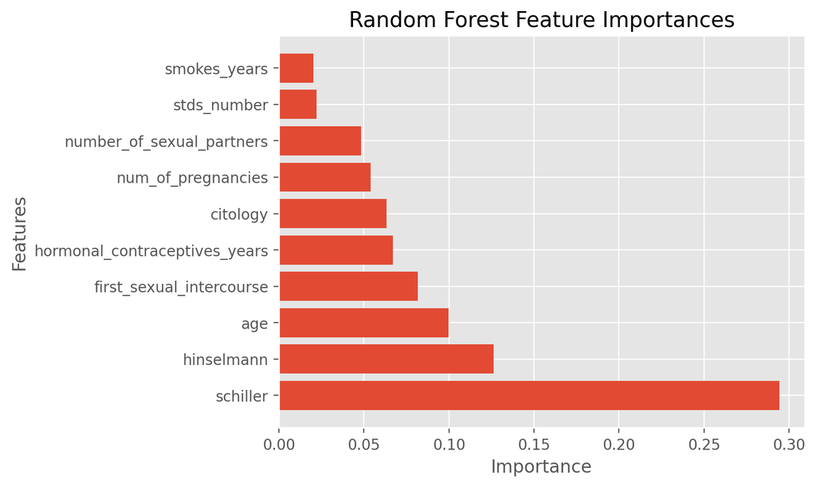

```python
plot_imp(best_features_rfi, feature_importances_rfi, 'Random Forest')
```

On observing the graph we see that Schiller Test, Hinselmann Test and age are the most important predictors for determining cervical cancer Biopsy result.

### Data Sampling and Train and Test Splitting

Since our dataset has 655 value, we will work with a sample of 300 rows. We do this by randomly selecting 300 rows and then out of these 300 rows, we train and test using 70:30 ratio.

We convert our pandas dataframe to a NumPy array to perform Sckitit-Learn

```python
# data sampling and train-test split
n_samples = 300

Data_sample = pd.DataFrame(Data).sample(n=n_samples, random_state=8).values
target_sample = pd.DataFrame(target).sample(n=n_samples, random_state=8).values

print(Data_sample.shape)
print(target_sample.shape)
```

```
(300, 20)
(300, 1)
```

```python
Data_sample_train, Data_sample_test, \
target_sample_train, target_sample_test = train_test_split(Data_sample, target_sample,
                                                    test_size = 0.3, random_state=999,
                                                    stratify = target_sample)

print(Data_sample_train.shape)
print(Data_sample_test.shape)
```

```
(210, 20)
(90, 20)
```

### Model Evaluation Strategy

We train 210 rows and then test 90 rows. For hyperparameter tuning, This code sets up a stratified k-fold cross-validation method with 5 folds, shuffling the data before splitting and ensuring reproducibility.

```python
cv_method = StratifiedKFold(n_splits=5, shuffle=True, random_state=999)
```

# Hyper Parameter Tuning

## 1.K-nearest Neighbors (KNN)

We employ a Pipeline to combine feature selection and grid search for tuning KNN hyperparameters through cross-validation. The same Pipeline approach will be used for Naive Bayes and Decision Trees

The hyperparameters for KNN are:

- Number of neighbors (n_neighbors)
- Distance metric (p)

```python
# custom function for RFI feature selection inside a pipeline
# here we use n_estimators=100
class RFIFeatureSelector(BaseEstimator, TransformerMixin):

    # class constructor
    # make sure class attributes end with a "_"
    # per scikit-learn convention to avoid errors
    def __init__(self, n_features_=10):
        self.n_features_ = n_features_
        self.fs_indices_ = None

    # override the fit function
    def fit(self, X, y):
        from sklearn.ensemble import RandomForestClassifier
        from numpy import argsort
        model_rfi = RandomForestClassifier(n_estimators=100)
        model_rfi.fit(X, y)
        self.fs_indices_ = argsort(model_rfi.feature_importances_)[::-1][0:self.n_features_]
        return self

    # override the transform function
    def transform(self, X, y=None):
        return X[:, self.fs_indices_]
```

```python
pipe_KNN = Pipeline(steps=[('rfi_fs', RFIFeatureSelector()),
                           ('knn', KNeighborsClassifier())])

params_pipe_KNN = {'rfi_fs__n_features_': [10, 20, Data.shape[1]],
                   'knn__n_neighbors': [1, 5, 10, 15, 20],
                   'knn__p': [1, 2]}

gs_pipe_KNN = GridSearchCV(estimator=pipe_KNN,
                           param_grid=params_pipe_KNN,
                           cv=cv_method,
                           refit=True,
                           n_jobs=-2,
                           scoring='roc_auc',
                           verbose=1)
```

```python
# converting our target from 2d to 1d
target_sample_train_1d = target_sample_train.ravel()
```

```python
gs_pipe_KNN.fit(Data_sample_train, target_sample_train_1d);
```

```
Fitting 5 folds for each of 30 candidates, totalling 150 fits
```

```python
gs_pipe_KNN.best_params_
```

```
{'knn__n_neighbors': 15, 'knn__p': 2, 'rfi_fs__n_features_': 20}
```

```python
gs_pipe_KNN.best_score_
```

```
0.911965811965812
```

```python
pred_KNN = gs_pipe_KNN.predict(Data_sample_test)
print("\nClassification report for K-Nearest Neighbor")
print(metrics.classification_report(target_sample_test, pred_KNN))
```

```
Classification report for K-Nearest Neighbor
              precision    recall  f1-score   support

           0       0.95      1.00      0.98        84
           1       1.00      0.33      0.50         6

    accuracy                           0.96        90
   macro avg       0.98      0.67      0.74        90
weighted avg       0.96      0.96      0.94        90
```

We note that the optimal KNN model achieved an average AUC score of 0.91. The best-performing KNN model selected 20 features, used 15 nearest neighbors, and employed the Euclidean distance metric. On studying the classification report we see he model performs well in correctly predicting negative instances (class 0) but struggles with identifying positive instances (class 1). There is room for improvement, particularly in increasing recall for class 1 to ensure better identification of positive cases.

```python
# custom function to format the search results as a Pandas data frame
def get_search_results(gs):

    def model_result(scores, params):
        scores = {'mean_score': np.mean(scores),
             'std_score': np.std(scores),
             'min_score': np.min(scores),
             'max_score': np.max(scores)}
        return pd.Series({**params,**scores})

    models = []
    scores = []

    for i in range(gs.n_splits_):
        key = f"split{i}_test_score"
        r = gs.cv_results_[key]
        scores.append(r.reshape(-1,1))

    all_scores = np.hstack(scores)
    for p, s in zip(gs.cv_results_['params'], all_scores):
        models.append((model_result(s, p)))

    pipe_results = pd.concat(models, axis=1).T.sort_values(['mean_score'], ascending=False)

    columns_first = ['mean_score', 'std_score', 'max_score', 'min_score']
    columns = columns_first + [c for c in pipe_results.columns if c not in columns_first]

    return pipe_results[columns]
```

```python
results_KNN = get_search_results(gs_pipe_KNN)
results_KNN.head()
```

|  | mean_score | std_score | max_score | min_score | knn__n_neighbors | knn__p | rfi_fs__n_features_ |
| --- | --- | --- | --- | --- | --- | --- | --- |
| 23 | 0.911966 | 0.067980 | 0.982906 | 0.82906 | 15.0 | 2.0 | 20.0 |
| 22 | 0.911966 | 0.067980 | 0.982906 | 0.82906 | 15.0 | 2.0 | 20.0 |
| 13 | 0.911111 | 0.066721 | 0.982906 | 0.82906 | 10.0 | 1.0 | 20.0 |
| 26 | 0.911111 | 0.067104 | 0.978632 | 0.82906 | 20.0 | 1.0 | 20.0 |
| 25 | 0.911111 | 0.067104 | 0.978632 | 0.82906 | 20.0 | 1.0 | 20.0 |

```python
print(results_KNN.columns)
```

```
Index(['mean_score', 'std_score', 'max_score', 'min_score', 'knn__n_neighbors',
       'knn__p', 'rfi_fs__n_features_'],
      dtype='object')
```

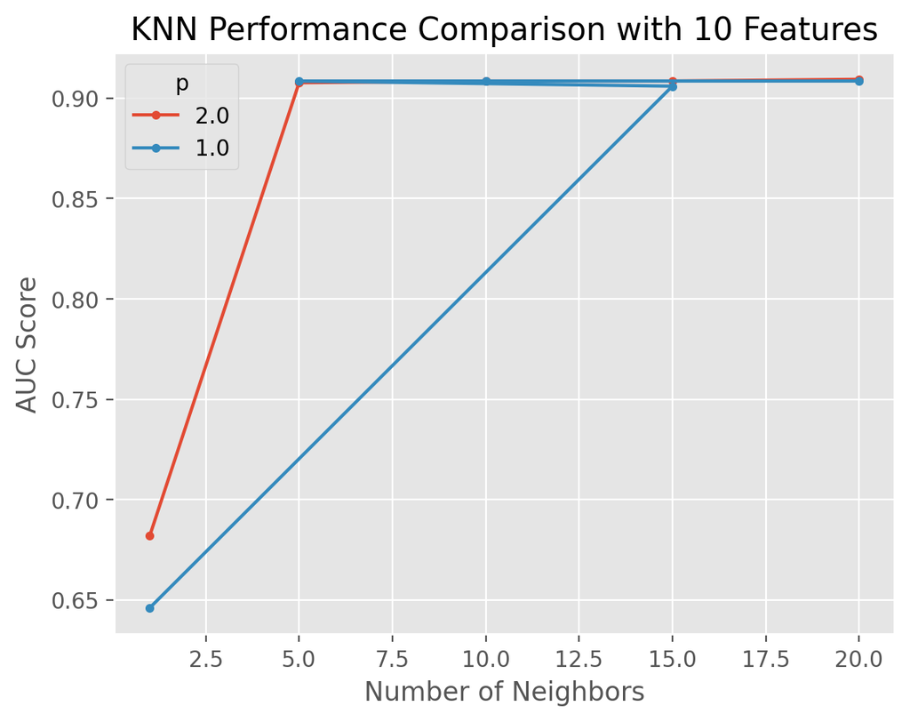

```python
results_KNN_10_features = results_KNN[results_KNN['rfi_fs__n_features_'] == 10.0]

for i in results_KNN_10_features['knn__p'].unique():
    temp = results_KNN_10_features[results_KNN_10_features['knn__p'] == i]
    plt.plot(temp['knn__n_neighbors'], temp['mean_score'], marker = '.', label = i)

plt.legend(title = "p")
plt.xlabel('Number of Neighbors')
plt.ylabel("AUC Score")
plt.title("KNN Performance Comparison with 10 Features")
plt.show()
```

Based on the plot we see that both manhattan and euclidean distance generate a higher than 0.9 accuarcy with 20 neighbours

## 2.(Gaussian) Naive Bayes (NB)

```python
target_sample_train_1d = target_sample_train.ravel()

# Transform the training data
Data_sample_train_transformed = PowerTransformer().fit_transform(Data_sample_train)

# Define the pipeline
pipe_NB = Pipeline([('rfi_fs', RFIFeatureSelector()),
                     ('nb', GaussianNB())])

# parameter grid
params_pipe_NB = {'rfi_fs__n_features_': [10, 20, Data.shape[1]],
                  'nb__var_smoothing': np.logspace(1, -3, num=200)}

# cross-validation method
cv_method = StratifiedKFold(n_splits=5, shuffle=True, random_state=999)

# Define the RandomizedSearchCV
n_iter_search = 20
gs_pipe_NB = RandomizedSearchCV(estimator=pipe_NB,
                          param_distributions=params_pipe_NB,
                          cv=cv_method,
                          refit=True,
                          n_jobs=-2,
                          scoring='roc_auc',
                          n_iter=n_iter_search,
                          verbose=1)

# Fit the model using the transformed data and the reshaped target variable
gs_pipe_NB.fit(Data_sample_train_transformed, target_sample_train_1d)
```

```
Fitting 5 folds for each of 20 candidates, totalling 100 fits
```

```
RandomizedSearchCV(cv=StratifiedKFold(n_splits=5, random_state=999, shuffle=True),
                   estimator=Pipeline(steps=[('rfi_fs', RFIFeatureSelector()),
                                             ('nb', GaussianNB())]),
                   n_iter=20, n_jobs=-2,
                   param_distributions={'nb__var_smoothing': array([1.00000000e+01, 9.54771611e+00, 9.11588830e+00, 8.70359136e+00,
       8.30994195e+00, 7.93409667e+00, 7.57525026e+00, 7.23263390e+00,
       6....
       2.40940356e-03, 2.30043012e-03, 2.19638537e-03, 2.09704640e-03,
       2.00220037e-03, 1.91164408e-03, 1.82518349e-03, 1.74263339e-03,
       1.66381689e-03, 1.58856513e-03, 1.51671689e-03, 1.44811823e-03,
       1.38262217e-03, 1.32008840e-03, 1.26038293e-03, 1.20337784e-03,
       1.14895100e-03, 1.09698580e-03, 1.04737090e-03, 1.00000000e-03]),
                                        'rfi_fs__n_features_': [10, 20, 20]},
                   scoring='roc_auc', verbose=1)
```

```python
gs_pipe_NB.best_params_
```

```
{'rfi_fs__n_features_': 20, 'nb__var_smoothing': 1.570290124729377}
```

```python
gs_pipe_NB.best_score_
```

```
0.9777777777777779
```

The optimal Naive Bayes yeilds a score of 0.97 with 20 features, which is more than KNN. Hence we can see that Naive Bayes performs better than KNN

```python
results_NB = get_search_results(gs_pipe_NB)
results_NB.head()
```

|  | mean_score | std_score | max_score | min_score | rfi_fs__n_features_ | nb__var_smoothing |
| --- | --- | --- | --- | --- | --- | --- |
| 2 | 0.977778 | 0.025123 | 1.0 | 0.931624 | 20.0 | 1.570290 |
| 3 | 0.977778 | 0.025123 | 1.0 | 0.931624 | 20.0 | 2.866068 |
| 5 | 0.977778 | 0.025123 | 1.0 | 0.931624 | 20.0 | 1.979167 |
| 19 | 0.976068 | 0.025006 | 1.0 | 0.931624 | 20.0 | 7.934097 |
| 12 | 0.976068 | 0.025006 | 1.0 | 0.931624 | 20.0 | 6.905514 |

Visualising these results

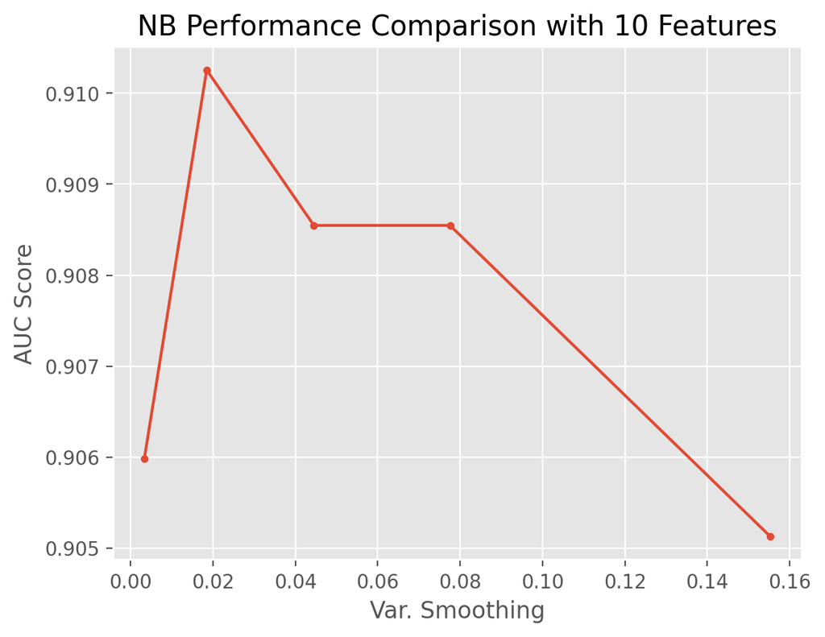

```python
results_NB_10_features = results_NB[results_NB['rfi_fs__n_features_'] == 10.0].sort_values('nb__var_smoothing')

plt.plot(results_NB_10_features['nb__var_smoothing'], results_NB_10_features['mean_score'], marker = '.', label = i)
plt.xlabel('Var. Smoothing')
plt.ylabel("AUC Score")
plt.title("NB Performance Comparison with 10 Features")
plt.show()
```

## 3. Decision Trees (DT)

We now make a decision tree where we use gini index and also aim to get the maximum depth and minimum sample split.

```python
target_sample_train_1d = target_sample_train.ravel()

pipe_DT = Pipeline([('rfi_fs', RFIFeatureSelector()),
                    ('dt', DecisionTreeClassifier(criterion='gini', random_state=45))])

params_pipe_DT = {'rfi_fs__n_features_': [10, 20, Data.shape[1]],
                  'dt__max_depth': [3, 4, 5],
                  'dt__min_samples_split': [2, 5]}

cv_method = StratifiedKFold(n_splits=5, shuffle=True, random_state=999)

gs_pipe_DT = GridSearchCV(estimator=pipe_DT,
                          param_grid=params_pipe_DT,
                          cv=cv_method,
                          refit=True,
                          n_jobs=-2,
                          scoring='roc_auc',
                          verbose=1)

gs_pipe_DT.fit(Data_sample_train, target_sample_train_1d)
```

```
Fitting 5 folds for each of 18 candidates, totalling 90 fits
```

```
GridSearchCV(cv=StratifiedKFold(n_splits=5, random_state=999, shuffle=True),
             estimator=Pipeline(steps=[('rfi_fs', RFIFeatureSelector()),
                                       ('dt',
                                        DecisionTreeClassifier(random_state=45))]),
             n_jobs=-2,
             param_grid={'dt__max_depth': [3, 4, 5],
                         'dt__min_samples_split': [2, 5],
                         'rfi_fs__n_features_': [10, 20, 20]},
             scoring='roc_auc', verbose=1)
```

```python
gs_pipe_DT.best_params_
```

```
{'dt__max_depth': 3, 'dt__min_samples_split': 5, 'rfi_fs__n_features_': 10}
```

```python
gs_pipe_DT.best_score_
```

```
0.829059829059829
```

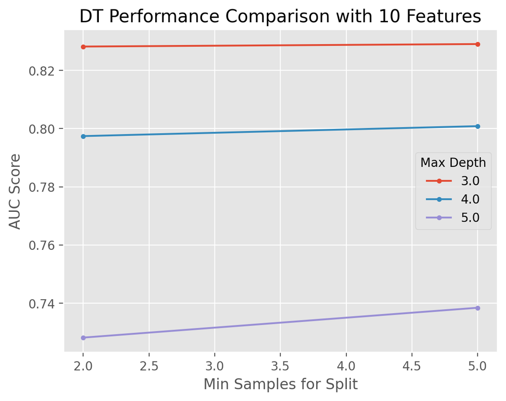

```python
results_DT = get_search_results(gs_pipe_DT)
results_DT_10_features = results_DT[results_DT['rfi_fs__n_features_'] == 10.0]


for i in results_DT_10_features['dt__max_depth'].unique():
    temp = results_DT_10_features[results_DT_10_features['dt__max_depth'] == i]
    plt.plot(temp['dt__min_samples_split'], temp['mean_score'], marker = '.', label = i)

plt.legend(title = "Max Depth")
plt.xlabel('Min Samples for Split')
plt.ylabel("AUC Score")
plt.title("DT Performance Comparison with 10 Features")
plt.show()
```

Max_depth of 3 with any min_samples_split provides the best and most stable AUC score of 0.82, indicating a good balance between model complexity and performance. The performance degradation with deeper trees (max_depth of 4 and 5) suggests that increasing depth does not necessarily improve model performance and may introduce sensitivity to other hyperparameters.

## 4.Neural networks

```python
#installed these already
#!pip install tensorflow
#!pip install keras
```

```python
# so that we can see all the columns
pd.set_option('display.max_columns', None)

# setup matplotlib
%matplotlib inline
%config InlineBackend.figure_format = 'retina'
plt.style.use("ggplot")
```

```python
# size of the network is determined by the number of neural units in each hidden layer
layer1_units = 4
layer2_units = 4

loss = 'binary_crossentropy'
# during training, we would like to monitor accuracy
metrics = ['accuracy']
epochs = 500
batch_size = 100
layer1_activation = 'relu'
layer2_activation = 'relu'
output_activation = 'sigmoid'
layer1_dropout_rate = 0.05
layer2_dropout_rate = 0.00
decay=1e-6
momentum=0.5
# SGD stands for stochastic gradient descent
optimizer = SGD(learning_rate=0.01, decay=decay, momentum=momentum)
```

```python
# set up an empty deep learning model
def model_factory(input_dim, layer1_units, layer2_units):
    model = Sequential()
    model.add(Dense(layer1_units, input_dim=input_dim, activation=layer1_activation))
    model.add(Dropout(layer1_dropout_rate))
    model.add(Dense(layer2_units, activation=layer1_activation))
    model.add(Dropout(layer2_dropout_rate))
    model.add(Dense(1, activation=output_activation))
    model.compile(loss=loss, optimizer=optimizer, metrics=metrics)
    return model
```

```python
# define plot function for the fit
# we will plot the accuracy here
def plot_history(history):
    plt.plot(history.history['accuracy'])
    plt.plot(history.history['val_accuracy'])
    plt.title('Model Accuracy')
    plt.ylabel('Accuracy')
    plt.xlabel('Epoch')
    plt.legend(['Train', 'Test'], loc='lower right')
    plt.show()
```

```python
model_test = model_factory(Data.shape[1], layer1_units, layer2_units)

# in the summary, notice the LARGE number of total parameters in the model
model_test.summary()
```

```
Model: "sequential"
```

```
┏━━━━━━━━━━━━━━━━━━━━━━━━━━━━━━━━━┳━━━━━━━━━━━━━━━━━━━━━━━━┳━━━━━━━━━━━━━━━┓
┃ Layer (type)                    ┃ Output Shape           ┃       Param # ┃
┡━━━━━━━━━━━━━━━━━━━━━━━━━━━━━━━━━╇━━━━━━━━━━━━━━━━━━━━━━━━╇━━━━━━━━━━━━━━━┩
│ dense (Dense)                   │ (None, 4)              │            84 │
├─────────────────────────────────┼────────────────────────┼───────────────┤
│ dropout (Dropout)               │ (None, 4)              │             0 │
├─────────────────────────────────┼────────────────────────┼───────────────┤
│ dense_1 (Dense)                 │ (None, 4)              │            20 │
├─────────────────────────────────┼────────────────────────┼───────────────┤
│ dropout_1 (Dropout)             │ (None, 4)              │             0 │
├─────────────────────────────────┼────────────────────────┼───────────────┤
│ dense_2 (Dense)                 │ (None, 1)              │             5 │
└─────────────────────────────────┴────────────────────────┴───────────────┘
```

```
 Total params: 109 (436.00 B)
```

```
 Trainable params: 109 (436.00 B)
```

```
 Non-trainable params: 0 (0.00 B)
```

```python
print(Data_sample_train.shape)
print(Data_sample_test.shape)
```

```
(210, 20)
(90, 20)
```

```python
%%time
history_test = model_test.fit(Data_sample_train,
                              target_sample_train,
                              epochs=epochs,
                              batch_size=batch_size,
                              verbose=0, # set to 1 for iteration details, 0 for no details
                              shuffle=True,
                              validation_data=(Data_sample_train, target_sample_train))
```

```
CPU times: user 6.95 s, sys: 819 ms, total: 7.77 s
Wall time: 6.7 s
```

```python
# here are the keys in the history attribute of the fitted model object
history_test.history.keys()
```

```
dict_keys(['accuracy', 'loss', 'val_accuracy', 'val_loss'])
```

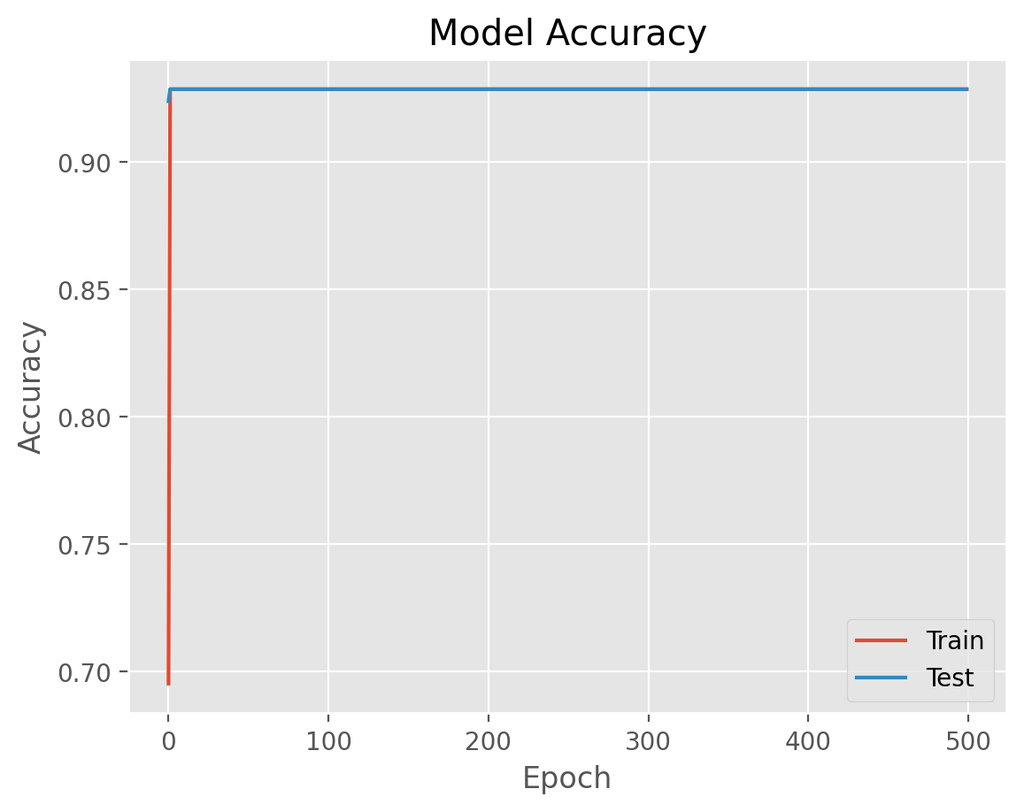

```python
plot_history(history_test)
```

```python
# compute prediction performance on test data
model_output = model_test.predict(Data_sample_test).astype(float)

# decide classification based on threshold of 0.5
t_pred = np.where(model_output < 0.5, 0, 1)

# set up the results data frame
result_test = pd.DataFrame()
result_test['target'] = target_sample_test.flatten()
result_test['fit'] = t_pred
# residuals will be relevant for regression problems
# result_test['abs_residual'] = np.abs(result_test['target'] - result_test['fit'])
result_test.head()
```

```
3/3 ━━━━━━━━━━━━━━━━━━━━ 0s 6ms/step
```

|  | target | fit |
| --- | --- | --- |
| 0 | 1 | 0 |
| 1 | 0 | 0 |
| 2 | 0 | 0 |
| 3 | 0 | 0 |
| 4 | 0 | 0 |

```python
acc = accuracy_score(result_test['target'], result_test['fit'])
auc = roc_auc_score(result_test['target'], result_test['fit'])
print(f"validation data accuracy_score = {acc:.3f}")
print(f"validation data roc_auc_score = {auc:.3f}")
```

```
validation data accuracy_score = 0.933
validation data roc_auc_score = 0.500
```

## Neural network Discussion

In this section, we provide a complete overview of the neural network model utilized in our predictive modelling project. The neural network architecture was designed to address the task of predicting cervical cancer risk based on a variety of patient attributes.

Training Configuration The success of our neural network hinges on meticulous training configuration tailored to our project's objectives. Leveraging the stochastic gradient descent (SGD) optimizer, we orchestrated the model's optimization process, striking a delicate balance between exploration and exploitation of the solution space. With a learning rate of 0.01, decay of 1e-6, and momentum of 0.5, the optimizer navigated the landscape of parameters, iteratively refining the model's performance over 500 epochs. At each iteration, a batch size of 100 facilitated efficient parameter updates, ensuring convergence towards an optimal solution. The choice of binary cross-entropy as the loss function, coupled with accuracy as the primary metric, exemplifies our commitment to robust model evaluation and validation.

In summary, our neural network model embodies the convergence of cutting-edge techniques and domain expertise in the quest to combat cervical cancer. By elucidating the intricacies of its architecture, parameter values, and training configuration, we pave the way for continued innovation and progress in predictive modelling for public health applications.

```python
#!pip install ml-dtypes==0.3.1
#!pip install tensorflow keras
#!pip install tensorflow keras --upgrade
```

```python
#conda install -c conda-forge keras
```

```python
# Define the neural network model
def create_model(input_dim, layer1_units=4, layer2_units=4, optimizer='adam'):
    model = Sequential()
    model.add(Dense(layer1_units, input_dim=input_dim, activation='relu'))
    model.add(Dropout(0.1))
    model.add(Dense(layer2_units, activation='relu'))
    model.add(Dropout(0.1))
    model.add(Dense(1, activation='sigmoid'))
    if optimizer == 'adam':
        optimizer = Adam()
    elif optimizer == 'rmsprop':
        optimizer = RMSprop()
    model.compile(loss='binary_crossentropy', optimizer=optimizer, metrics=['accuracy'])
    return model

# Create a custom wrapper
class KerasClassifierWrapper(BaseEstimator, ClassifierMixin):
    def __init__(self, input_dim, layer1_units=4, layer2_units=4, optimizer='adam', epochs=10, batch_size=10, verbose=0):
        self.input_dim = input_dim
        self.layer1_units = layer1_units
        self.layer2_units = layer2_units
        self.optimizer = optimizer
        self.epochs = epochs
        self.batch_size = batch_size
        self.verbose = verbose
        self.model_ = None
        self._create_model_fn = lambda: create_model(self.input_dim, self.layer1_units, self.layer2_units, self.optimizer)

    def fit(self, X, y, **fit_params):
        self.model_ = self._create_model_fn()
        self.model_.fit(X, y, epochs=self.epochs, batch_size=self.batch_size, verbose=self.verbose, **fit_params)
        return self

    def predict(self, X):
        return (self.model_.predict(X) > 0.5).astype("int32")

    def score(self, X, y):
        return accuracy_score(y, self.predict(X))

# Wrap the Keras model into the custom wrapper
input_dim = Data_sample_train.shape[1]
keras_model = KerasClassifierWrapper(input_dim=input_dim)

# Define the grid search parameters
param_grid = {
    'layer1_units': [4, 8, 16],
    'layer2_units': [4, 8, 16],
    'optimizer': ['adam', 'rmsprop']
}

# Create and perform GridSearchCV using the training data
model = GridSearchCV(estimator=keras_model, param_grid=param_grid, cv=3)
grid_result = model.fit(Data_sample_train, target_sample_train)
```

[output not shown]

```python
# Summarize results
print("Best: %f using %s" % (grid_result.best_score_, grid_result.best_params_))

# Make predictions on the test set
predictions = grid_result.predict(Data_sample_test)
print(f"Predictions shape: {predictions.shape}")

# Check the number of samples in Data_sample_test
print(f"Data_sample_test shape: {Data_sample_test.shape}")

# Use actual test labels for accuracy calculation
true_labels = target_sample_test

# Check the length of true_labels
print(f"True labels shape: {true_labels.shape}")

# Calculate accuracy
accuracy = accuracy_score(true_labels, predictions)
print(f"Accuracy: {accuracy:.2f}")
```

```
Best: 0.928571 using {'layer1_units': 4, 'layer2_units': 4, 'optimizer': 'adam'}
3/3 ━━━━━━━━━━━━━━━━━━━━ 0s 5ms/step
Predictions shape: (90, 1)
Data_sample_test shape: (90, 20)
True labels shape: (90, 1)
Accuracy: 0.93
```

## Model Comparision

Upon evaluating the performance of four machine learning models—K-Nearest Neighbors (KNN), Naive Bayes (NB), Decision Tree (DT), and Neural Network (NN)—we observed varying degrees of success in capturing patterns and discriminating between classes in the dataset. To compare them we perform t-test to get relevant results

```python
mean_roc_auc_KNN = results_KNN['mean_score'].mean()
print("Mean ROC AUC for KNN:", mean_roc_auc_KNN)
```

```
Mean ROC AUC for KNN: 0.8580911680911681
```

```python
mean_roc_auc_NB = results_NB['mean_score'].mean()
print("Mean ROC AUC for NB:", mean_roc_auc_NB)
```

```
Mean ROC AUC for NB: 0.9299999999999999
```

```python
mean_roc_auc_DT = results_DT['mean_score'].mean()
print("Mean ROC AUC for DT:", mean_roc_auc_DT)
```

```
Mean ROC AUC for DT: 0.7837606837606836
```

```python
acc = accuracy_score(result_test['target'], result_test['fit'])
auc = roc_auc_score(result_test['target'], result_test['fit'])
print(f"validation data accuracy_score for NN = {acc:.3f}")
print(f"validation data roc_auc_score for NN = {auc:.3f}")
```

```
validation data accuracy_score for NN = 0.933
validation data roc_auc_score for NN = 0.500
```

### Performing T-test for all our model pairs

```python
# Perform a t-test
t_statistic, p_value = ttest_ind(results_KNN['mean_score'], results_NB['mean_score'])

# Print the results
print("Mean ROC AUC for KNN:", mean_roc_auc_KNN)
print("Mean ROC AUC for Naive Bayes:", mean_roc_auc_NB)
print("T-statistic:", t_statistic)
print("P-value:", p_value)

# Interpret the results
if p_value < 0.05:
    print("There is a statistically significant difference between the mean ROC AUC scores of KNN and Naive Bayes.")
else:
    print("There is no statistically significant difference between the mean ROC AUC scores of KNN and Naive Bayes.")
```

```
Mean ROC AUC for KNN: 0.8580911680911681
Mean ROC AUC for Naive Bayes: 0.9299999999999999
T-statistic: -3.3166557864320017
P-value: 0.0017418369132242541
There is a statistically significant difference between the mean ROC AUC scores of KNN and Naive Bayes.
```

```python
# Perform a t-test
t_statistic, p_value = ttest_ind(results_NB['mean_score'], results_DT['mean_score'])

# Print the results
print("Mean ROC AUC for Naive Bayes:", mean_roc_auc_NB)
print("Mean ROC AUC for Decision Trees:", mean_roc_auc_DT)
print("T-statistic:", t_statistic)
print("P-value:", p_value)

# Interpret the results
if p_value < 0.05:
    print("There is a statistically significant difference between the mean ROC AUC scores of Naive Bayes and Decision Trees.")
else:
    print("There is no statistically significant difference between the mean ROC AUC scores of Naive Bayes and Decision Trees.")
```

```
Mean ROC AUC for Naive Bayes: 0.9299999999999999
Mean ROC AUC for Decision Trees: 0.7837606837606836
T-statistic: 12.753838171470909
P-value: 6.44368528878804e-15
There is a statistically significant difference between the mean ROC AUC scores of Naive Bayes and Decision Trees.
```

```python
# Perform a t-test
t_statistic, p_value = ttest_ind(results_KNN['mean_score'], results_DT['mean_score'])

# Print the results
print("Mean ROC AUC for KNN:", mean_roc_auc_KNN)
print("Mean ROC AUC for Decision Trees:", mean_roc_auc_DT)
print("T-statistic:", t_statistic)
print("P-value:", p_value)

# Interpret the results
if p_value < 0.05:
    print("There is a statistically significant difference between the mean ROC AUC scores of KNN and Decision Trees.")
else:
    print("There is no statistically significant difference between the mean ROC AUC scores of KNN and Decision Trees.")
```

```
Mean ROC AUC for KNN: 0.8580911680911681
Mean ROC AUC for Decision Trees: 0.7837606837606836
T-statistic: 3.1657765896116166
P-value: 0.0027437896985004337
There is a statistically significant difference between the mean ROC AUC scores of KNN and Decision Trees.
```

```python
# Perform a t-test
t_statistic, p_value = ttest_ind(results_KNN['mean_score'], acc)

# Print the results
print("Mean ROC AUC for KNN:", mean_roc_auc_KNN)
print("Mean ROC AUC for Neural Network:", auc)
print("T-statistic:", t_statistic)
print("P-value:", p_value)

# Interpret the results
if p_value < 0.05:
    print("There is a statistically significant difference between the mean ROC AUC scores of KNN and Neural Network.")
else:
    print("There is no statistically significant difference between the mean ROC AUC scores of KNN and Neural Network.")
```

```
Mean ROC AUC for KNN: 0.8580911680911681
Mean ROC AUC for Neural Network: 0.5
T-statistic: -0.7884167405374423
P-value: 0.4368508601206914
There is no statistically significant difference between the mean ROC AUC scores of KNN and Neural Network.
```

```python
# Perform a t-test
t_statistic, p_value = ttest_ind(results_NB['mean_score'], acc)

# Print the results
print("Mean ROC AUC for NB:", mean_roc_auc_NB)
print("Mean ROC AUC for Neural Network:", auc)
print("T-statistic:", t_statistic)
print("P-value:", p_value)

# Interpret the results
if p_value < 0.05:
    print("There is a statistically significant difference between the mean ROC AUC scores of NB and Neural Network.")
else:
    print("There is no statistically significant difference between the mean ROC AUC scores of NB and Neural Network.")
```

```
Mean ROC AUC for NB: 0.9299999999999999
Mean ROC AUC for Neural Network: 0.5
T-statistic: -0.11517566580827446
P-value: 0.909514403678441
There is no statistically significant difference between the mean ROC AUC scores of NB and Neural Network.
```

```python
# Perform a t-test
t_statistic, p_value = ttest_ind(results_DT['mean_score'], acc)

# Print the results
print("Mean ROC AUC for DT:", mean_roc_auc_DT)
print("Mean ROC AUC for Neural Network:", auc)
print("T-statistic:", t_statistic)
print("P-value:", p_value)

# Interpret the results
if p_value < 0.05:
    print("There is a statistically significant difference between the mean ROC AUC scores of DT and Neural Network.")
else:
    print("There is no statistically significant difference between the mean ROC AUC scores of DT and Neural Network.")
```

```
Mean ROC AUC for DT: 0.7837606837606836
Mean ROC AUC for Neural Network: 0.5
T-statistic: -3.483992194272061
P-value: 0.002840940703207019
There is a statistically significant difference between the mean ROC AUC scores of DT and Neural Network.
```

## Critique and Limitations

**Limitations:**

1. **Feature Selection:** If the feature set used for predictive modeling is not comprehensive or relevant, it may lead to suboptimal performance. Ensuring the inclusion of clinically relevant features and effective feature selection techniques could enhance the model's predictive accuracy.
2. **Imbalanced Data:** Imbalanced datasets, where one class (e.g., benign (0) or malignant(1)) is significantly more prevalent than the other, can bias model predictions towards the majority class. Implementing techniques such as oversampling, undersampling, or utilizing specialized algorithms for handling imbalanced data could mitigate this issue.
3. **Model Interpretability:** Decision Trees and Neural Networks, while effective in predictive modeling, often lack interpretability compared to Naive Bayes and KNN. Understanding the rationale behind model predictions is crucial, especially in medical contexts where interpretability is essential for decision-making.
4. **Hyperparameter Tuning:** The performance of machine learning models is sensitive to hyperparameters, and suboptimal hyperparameter values can impact model performance. Exhaustive hyperparameter tuning may be computationally expensive and prone to overfitting, necessitating careful selection and validation of hyperparameters.

**Strengths:**

1. **Diverse Modeling Approaches:** By employing a variety of classifiers such as KNN, Decision Trees, Naive Bayes, and Neural Networks, your approach harnesses the strengths of different algorithms, enabling a comprehensive exploration of the data landscape and potentially capturing complex relationships.
2. **Robustness:** Utilizing multiple classifiers enhances the robustness of your predictive modeling approach. If one model underperforms due to inherent biases or limitations, others may compensate, leading to more reliable predictions overall.
3. **Scalability:** KNN, Decision Trees, Naive Bayes, and Neural Networks are scalable algorithms that can handle datasets of varying sizes. This scalability facilitates the application of your predictive modeling approach to large-scale datasets encountered in clinical settings.
4. **Generalizability:** A well-constructed predictive modeling approach can generalize to unseen data, providing valuable insights and predictions beyond the training dataset. Cross-validation techniques and rigorous evaluation metrics help assess the generalizability of your models.

## Conclusion

Our dataset contains various patient attributes, including demographic data, sexual behavior, smoking habits, contraceptive usage, history of sexually transmitted diseases (STDs), and diagnostic outcomes related to cervical cancer. This project was divided into two main phases: data cleaning and predictive modeling.

Phase 1: Data Cleaning and Exploration In the initial phase, our primary goal was to prepare the dataset for analysis. We identified the biopsy result as our target variable. Through meticulous data cleaning, we removed null values and inconsistencies to ensure the reliability of our analyses. We then explored the relationships between the variables to understand how they influence each other. Visualizations provided valuable insights into trends, such as the prevalence of cervical cancer risk factors across different demographic groups and the impact of certain behaviors on disease incidence. This exploratory analysis laid a strong foundation for the predictive modeling phase.

Phase 2: Predictive Modeling In the second phase, we focused on predictive modeling to determine the likelihood of cervical cancer based on the patient attributes. We identified the most significant features contributing to the prediction using feature importance techniques, finding that the Hinselmann result, Schiller result, and age were the most important features in predicting the correct biopsy result. We then split the dataset into training and testing sets in a 70:30 ratio to evaluate our models effectively. We employed several machine learning algorithms, including K-Nearest Neighbors (KNN), Naive Bayes, Decision Trees, and Neural Networks.

Given these results, the Naive Bayes classifier is the most effective model for predicting cervical cancer biopsy results in this dataset, followed by KNN and Decision Trees. The identification of key features, such as the Hinselmann result, Schiller result, and age, further enhances the predictive accuracy of our models. These findings will greatly assist in predicting cancer biopsy results, providing valuable support for clinical decision-making and potentially improving patient outcomes. This project highlights the importance of data preprocessing and the value of comparative analysis in selecting the most suitable predictive model for medical diagnostics.